# Analysing Spatiotemporal Health Data

Theresa Smith

Friday 3 September 2021

# Plan for this session

- Motivating example
- Background on modelling areal health data
- Demo with R-INLA
  - Link to fill-in-the-blank R notebook for demo on [my GitHub](https://github.com/smithtr/SpatialHealthOGH/blob/main/Main_Session/SpatialHealthDemo.Rmd).
- Extensions

Link to full code in slides also on [my GitHub](https://github.com/smithtr/SpatialHealthOGH/blob/main/Main_Session/AnalysingSpatialHealthSlides.Rmd).

# Uptake of first dose of COVID-19 Vaccines in London MSOAs

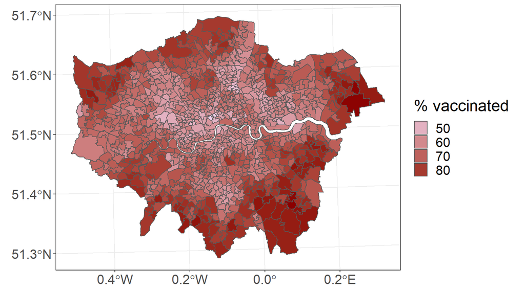

- Percent adults (16+) who received first dose in London MSOAs up to 22 August.
  - From the [UK Covid Data Dashboard](https://coronavirus.data.gov.uk/).
- Clear spatial pattern with higher rates on the outskirts than in the center.
  - What socio-demographic characteristics explain this spatial pattern? Are there any ‘at risk’ areas?

# Philosophy of spatial modelling

- If we were omniscient and could measure everything:

```r
vax_rate ~ f(feature1, feature2,..., feature100)
```

- Since we aren’t omniscient, we add some error:

```r
vax_rate ~ f(feature1, feature2, feature3) + error
```

- If our data have some structure, we add in some random effects:

```r
vax_rate ~ f(feature1, feature2, feature3) + error + re(structure)
```

# Features in our example

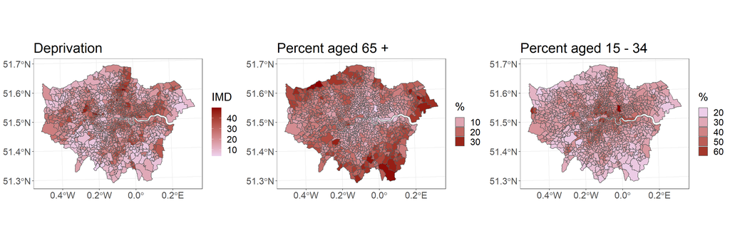

- Mid 2019 proportion of population 15 - 34 and 65+ from the [Office for National Statistics](https://www.ons.gov.uk/peoplepopulationandcommunity/populationandmigration/populationestimates/datasets/middlesuperoutputareamidyearpopulationestimates)
- 2019 Deprivation from ONS, up-scaled by the [University of Sheffield](https://research.mysociety.org/sites/imd2019/about/)

# Initial modelling

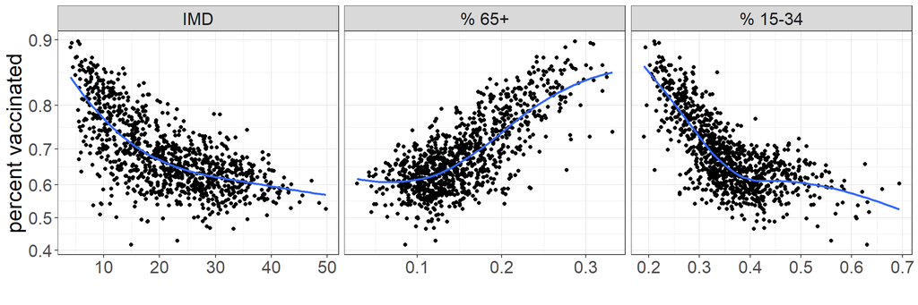

```r
logit_base = glm(cbind(Y, n-Y)~ IMD+ I(IMD^2)+ old + young*I(young<0.4), data = London_Vax, family = 'binomial')
```

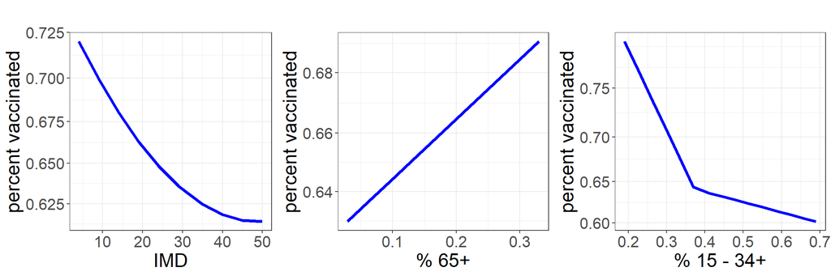

# Residuals

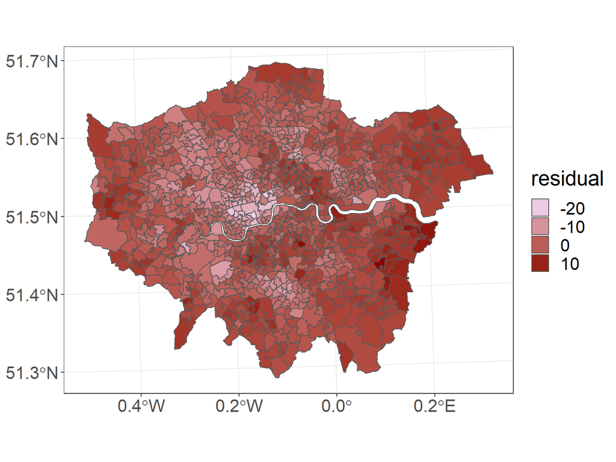

Reminder of our general strategy:

```r
vax_rate ~ f(feature1, feature2, feature3) + error + re(structure)
```

# Modelling Areal Health Data

- Suppose we have $m$ non overlapping areas $A_i, \dots, A_m$ and $y_i$ is the number of cases or events in area $A_i$.
- Classical spatial health models are based on the adjacency matrix $W$ where $w_{ij} = 1$ if $A_i$ and $A_j$ share a border.

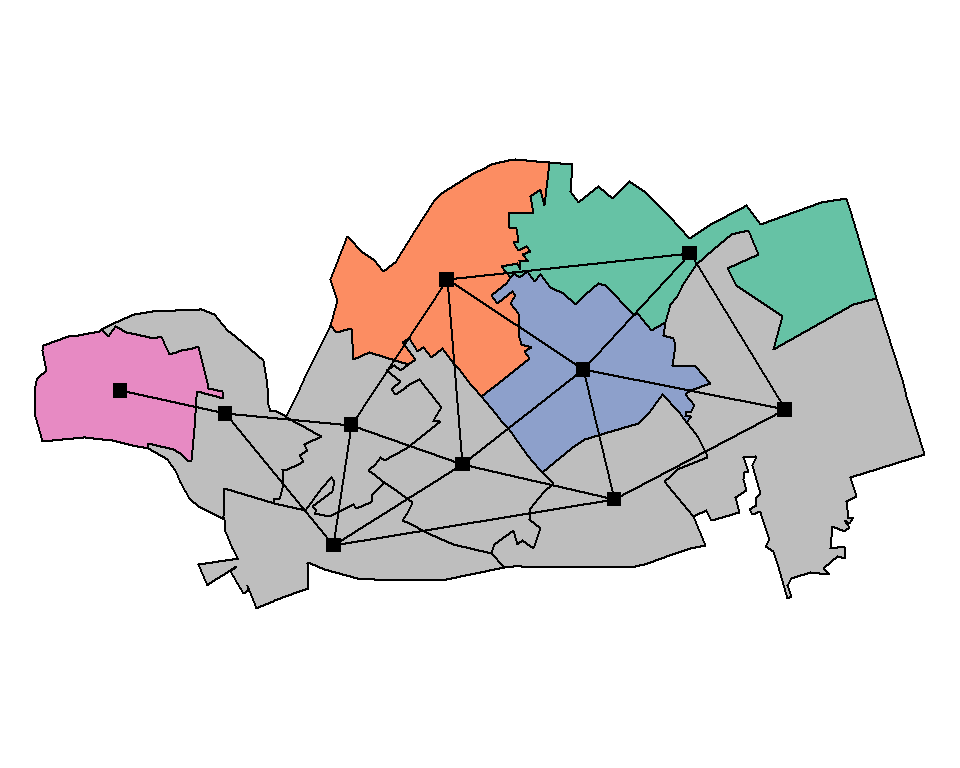

Snippet of the spatial adjacency matrix

```
##   G O B P
## G 0 1 1 0
## O 1 0 1 0
## B 1 1 0 0
## P 0 0 0 0
```

- The `spdep` package has tools for making the adjacency matrix from a spatial object

```r
London_NB = poly2nb(MSOA_London)
London_W = nb2mat(London_NB, style = 'B')
```

# Spatial Generalised Linear Mixed Model

- Spatial logistic model

$$\begin{align*}
y_i & \sim \mathsf{Binom}(N_i, \theta_i),\\
\mathrm{logit}(\theta_i) & = x'_i \beta + v_i + u_i,\\
\mathbf{v} & \sim \mathsf{N}(0, \gamma^{-2}),\\
\mathbf{u} & \sim \mathsf{H}
\end{align*}$$
where $H$ is some distribution with spatial structure.

- Classical choice for $H$ is the intrinsic conditional auto-regressive model (ICAR), specified by a set of conditionals

$$\begin{align*}
u_i \mid \mathbf{u}_{-i}\sim \mathsf{N}\left( \frac{\sum_{j} W_{ij} u_j}{\sum_j W_{ij}}, \frac{\tau^2}{\sum_j W_{ij}} \right) = \mathsf{N}\left( \frac{\sum_{j\in \mathrm{nb}(i)} u_j}{|\mathrm{nb}(i)|}, \frac{\tau^2}{|\mathrm{nb}(i)|} \right),
\end{align*}$$
where $\mathrm{nb}(i)$ is the set of areas that neighbor area $i$.

- This is called the BYM model after Besag, York, and Mollié (1991). “Bayesian image restoration, with two applications in spatial statistics.” doi:10.1007/BF00116466.

# BYM implementation in INLA

- The BYM model can be fit using MCMC (see for example `CARBayes`) or `INLA`.
- INLA is a general tool for approximating marginal posterior distributions in Bayesian hierarchical models with latent Gaussian components:

$$\begin{align*}
\mathbf{y} \sim f(\mathbf{u}, \theta_1), \qquad
\mathbf{u} \sim \mathsf{N}(0, \Sigma(\theta_2)), \qquad
\theta & \sim \pi(\theta).
\end{align*}$$

- Tailored for fast approximations of $\pi(u_i \mid \mathbf{y})$ and $\pi(\theta_i \mid \mathbf{y})$ when $\Sigma^{-1}(\theta_2)$ is sparse.
- Model syntax is similar to `lm` or `glm` with latent models encoded using `f(, model = )`
  - `f(i, mode = 'iid')` for v.
  - `f(i, mode = 'besag', graph = )` for u.
  - `f(i, mode = 'bym', graph = )` to do both all in one.

# Demo

This slide is here to remind me to switch over to a live demo!

[figure not shown]

# BYM London Data

- First need to add in some columns for random effects index:

```r
London_Vax_INLA = mutate(London_Vax, IDv = 1:nrow(London_Vax), IDu = IDv)
```

- Next, run INLA!

```r
London_BYM = inla(Y ~ IMD+ I(IMD^2)+ old + young*I(young<0.4) + f(IDv, model = 'iid')+
                    f(IDu, model = "besag", graph = London_W), Ntrials = n,
                     data = London_Vax_INLA, family = 'binomial')
London_BYM$summary.fixed[c('mean','sd','0.025quant','0.975quant')]
```

```
##                                   mean           sd    0.025quant    0.975quant
## (Intercept)               1.1846596003 1.050730e-01  0.9783403730  1.3908361860
## IMD                      -0.0299770720 2.937829e-03 -0.0357466517 -0.0242133014
## I(IMD^2)                  0.0003301785 5.673632e-05  0.0002187726  0.0004415078
## old                       1.3314509392 2.501972e-01  0.8401083080  1.8223396225
## young                    -0.6432201862 1.845816e-01 -1.0057068669 -0.2810701953
## I(young < 0.4)TRUE        0.6547697783 1.077467e-01  0.4431868851  0.8661801309
## young:I(young < 0.4)TRUE -1.7110942602 2.703873e-01 -2.2420662385 -1.1805764496
```

- Compare regression coefficients to the GLM estimates

```
##      Int    IMD   IMD^2 %65+ %15-34 %15-34<0.4 (%15-34):(%15-34<0.4)
## GLM  1.0 -0.023 0.00024  0.9  -0.53       1.40                  -3.6
## INLA 1.2 -0.030 0.00033  1.3  -0.64       0.65                  -1.7
```

# Random Effects

- Posterior summaries of $\gamma^2$ and $\tau^2$ (which are precisions rather than variances)

```r
London_BYM$summary.hyperpar[c('mean','sd','0.025quant','0.975quant')]
```

```
##                           mean           sd  0.025quant  0.975quant
## Precision for IDv 24357.865428 2.715552e+04 2017.319508 95527.62999
## Precision for IDu     9.749202 4.560412e-01    8.881741    10.67612
```

- Extract and inspect $\hat v$’s and $\hat u$’s

```r
London_Vax$v = London_BYM$summary.random$IDv$mean
London_Vax$u = London_BYM$summary.random$IDu$mean
```

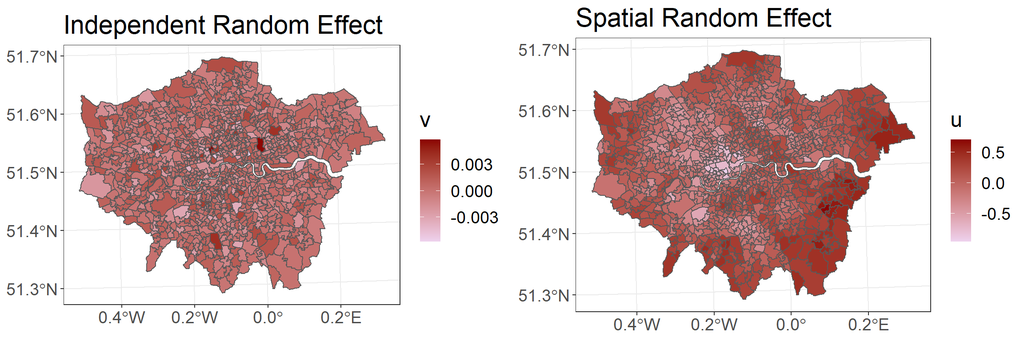

Negative values: odds of vaccination lower than we would expect given deprivation and age structure.

# Identifying concerning areas

Question: which MSOAs have substantially lower odds of vaccination after accounting for deprivation and age structure?

$$p(v_i+u_i < \text{threshold})$$

Can calculate such quantities with `inla.pmarginal`

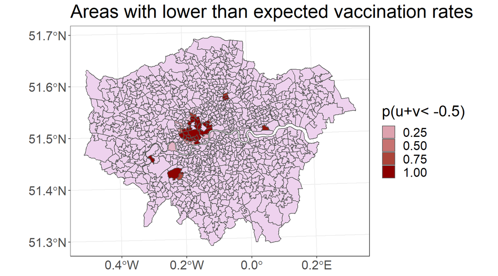

```r
London_BYMv2 = inla(Y ~ IMD+ I(IMD^2)+ old + young*I(young<0.4) + f(IDu, model = "bym", graph = London_W),
                    Ntrials = n, data = London_Vax_INLA, family = 'binomial')

exceed_probs = vector(length = nrow(London_Vax))
for(i in 1:nrow(London_Vax)) exceed_probs[i] = inla.pmarginal(q = -0.5, marginal = London_BYMv2$marginals.random$ID[[i]])
London_Vax$exceed_probs =  exceed_probs
```

# Caveats

- Exceedence calculations depend on our regression model being correct.
- Regression coefficients are *ecological* log odds ratios. Interpreting them as an individual-level association corresponds to a belief that the average exposure is causative.
- Attempting to infer individual-level effects from group-level (here, MSOA-level) data is called the *ecological fallacy*.
- One should be cautions about over-interpreting spatial regression, but area-level analysis can add to the totality of evidence for a hypothesis.

# Extensions

- There is nothing special about the binomial model here. Poisson is more common for rare health outcomes (e.g., cancer incidence or mortality).
- Can add temporal random effects and space-time interactions. For example

$$\begin{align*}
y_{it} & \sim \mathsf{Binom}(N_{it}, \theta_{it}),\\
\mathrm{logit}(\theta_{it}) & = x'_{it} \beta + v_i + u_i + b_t + d_{it},\\
\mathbf{b} & \sim \mathsf{AR1}(\rho, \kappa),\\
\mathbf{d} & \sim \mathsf{N}(0, \Sigma_S \otimes \Sigma_T)
\end{align*}$$

- These types of models are also available in `inla`
  - `f(t, model = 'ar1')` other options are `f(t, model = 'rw1')` or `f(t, model = 'rw2')`
  - `f(i, model = 'besag', graph = , group = t, control.group = list(model = 'ar1'))`
- Active research areas
  - Prior specification for fixed effecs and variances (which I totally ignored)
  - Continuous spatial models for $u$ such as $u \sim \mathsf{GP}$ via INLA-SPDE

# Resources

- INLA webpage: https://www.r-inla.org/examples-tutorials
- Paula Moraga’s book [Geospatial Health Data: Modeling and Visualization with R-INLA and Shiny](https://www.paulamoraga.com/book-geospatial/)
- Virgilio Gómez-Rubio book [Bayesian inference with INLA](https://becarioprecario.bitbucket.io/inla-gitbook/)

### Thank you!

Get in touch with me

- email: t.r.smith@bath.ac.uk
- Twitter: @TheresaRSmith